# Johns Hopkins University Data Science Capstone Project Milestone Report

Richard Allen

2022-04-24

# 1 Executive Summary

The following report examines the data required for the Johns Hopkins Data Science Specialization Capstone Project and explores plans for creating a word prediction app. Of three model types trialled (Recursive Neural Network with TensorFlow, Markov Chain Prediction and Stupid Back-off), the report will find the Stupid Back-off approach to be the best performer in terms of accuracy, speed and size, and simplest to create.

# 2 Project Task

Using data obtained from the coursera website representing publicly available text from twitter, news and blog sources, create a predictive text product that takes as input a phrase (multiple words) and predict the next word.

# 3 Obtaining the Data

## 3.1 Downloading the Source Text

- The [Coursera material](https://d396qusza40orc.cloudfront.net/dsscapstone/dataset/Coursera-SwiftKey.zip) is downloaded and extracted
- An [English profanity filter](https://raw.githubusercontent.com/LDNOOBW/List-of-Dirty-Naughty-Obscene-and-Otherwise-Bad-Words/master/en) is downloaded, required for cleaning the data.

## 3.2 Load the data and combine the sources.

This project will just look at the en_US data set:

- The three data sources are loaded and combined into a single data set

```
## # A tibble: 10 x 3
##    text                                                            source     id
##    <chr>                                                           <chr>   <int>
##  1 "I hate when people say volleyball isn't a sport."              twitt~ 2.02e6
##  2 "Great seieing you, too! Congrats for your wins as well. Every~ twitt~ 3.33e6
##  3 "thanks so much, Lyndsay - for the warm welcome back and for y~ twitt~ 3.27e6
##  4 "Up way too early so I can be at my school by 7 for a literary~ twitt~ 2.78e6
##  5 "Just handed Kraig Karson Lil Wayne's \"Green & Yellow\" to de~ twitt~ 3.72e6
##  6 "EK Success border punch."                                      blog   4.03e5
##  7 "Don’t think in terms of creating for a child; think of creati~ blog   5.83e5
##  8 "Wanna see it go mano-a-mano w/ RT think Monkey Puzzle tree b/~ twitt~ 2.77e6
##  9 "\"Do you close a fire station, or do you close mounted patrol~ news   9.45e5
## 10 "616. Salad @ Tiki Bar (Spring Mt., PA) 4:48 p.m."              blog   4.02e5
```

## 3.3 Initial Filter

- The blog set contains many garbage entries with less than 5 characters. Filter all text lines from the data set shorter than 5 characters.
- Duplicate lines are removed from the data set.

Sample size after initial filter:

- Blogs: 897,476
- News: 1,009,807
- Twitter: 2,359,859

## 3.4 Create Sample Sets for Training, Testing and Validation

- Each set is taken proportionally from the source data.
- With 4,267,142 rows in the combined data set, 10% is a sufficient size for training, with 5% each for testing and validation.

Data set sizes:

- Training: 426,714 rows
- Testing: 213,357 rows
- Validation: 213,357 rows

# 4 Preparing the Data Sample Sets

## 4.1 Clean Sample

The following process is performed on the subsets prepared above:

1. convert to lower-case and strip out profanity
2. replace smart single quote ’ with ’
3. replace all sentence terminating characters with a full stop
4. remove all remaining punctuation except single quote and full stop

## 4.2 Save Data Sets

Prepared data sets for later use in modelling.

## 4.3 Corpus

The Quanteda package is used to create the corpus representing all the text in the sample and for all subsequent data analysis in this document.

## 4.4 Create Tokens

Tokenisation is the process of splitting the corpus into sentences and/or words with relative frequencies.

- Two sets are created, with and without stop words. Without stop words is useful for analysis, however they will be needed for text prediction later on.
- A filter for profanity is applied first.
- URL’s removed and any remaining symbols when creating the tokens.

Sample token collections with and without stop words:

```
## Tokens consisting of 6 documents and 1 docvar.
## text237392 :
## [1] "i"        "am"       "feeling"  "a"        "little"   "stressed" "out"
##
## text106390 :
##  [1] "my"      "friend"  "james"   "from"    "atlanta" "georgia" "had"
##  [8] "chosen"  "to"      "shave"   "his"     "legs"
## [ ... and 59 more ]
##
## text304108 :
##  [1] "haters"     "don't"      "really"     "hate"       "you"
##  [6] "they"       "hate"       "themselves" "cuz"        "your"
## [11] "a"          "reflection"
## [ ... and 6 more ]
##
## text408457 :
## [1] "i"            "love"         "my"           "grandparents" "so"
## [6] "much"
##
## text295846 :
##  [1] "omg"    "yes"    "i"      "had"    "to"     "drink"  "a"      "ton"
##  [9] "of"     "water"  "before" "mine"
## [ ... and 7 more ]
##
## text126055 :
##  [1] "on"           "the"          "other"        "hand"         "a"
##  [6] "good"         "review"       "is"           "heartwarming" "and"
## [11] "may"          "help"
## [ ... and 64 more ]
```

```
## Tokens consisting of 6 documents and 1 docvar.
## text382554 :
##  [1] "new"            "mone"           "single"         "stars"
##  [5] "hands"          "www.itunes.com" "search"         "mack"
##  [9] "mone"           "doin"           "bad"
##
## text345167 :
## [1] "love"    "already" "new"     "paltz"   "girls"   "looks"
##
## text342900 :
## [1] "teeth"     "pants"     "pants"     "human"     "centipede" "pants"
##
## text347518 :
##  [1] "nice"         "weather"      "brings"       "rebent"       "cyclists"
##  [6] "austin"       "yet"          "see"          "one"          "helmed"
## [11] "smug.looking" "bearded"
## [ ... and 2 more ]
##
## text249732 :
## [1] "little" "boy"    "sister" "says"   "can"    "er"     "comes"
##
## text322088 :
##  [1] "yes"      "eating"   "outside"  "better"   "choice"   "jared's"
##  [7] "bo"       "tweets"   "cracking" "btw"
```

- There are 9,967,883 words in the corpus, 5,472,644 without stop words.

# 5 Exploratory Data Analysis

## 5.1 Corpus Structure

| feature | Source | mean | sd | p0 | p25 | p50 | p75 | p100 |
| --- | --- | --- | --- | --- | --- | --- | --- | --- |
| Words | blog | 44.323272 | 48.3291100 | 0 | 9 | 30 | 63 | 1750 |
| Words | news | 36.129679 | 23.6054932 | 0 | 20 | 33 | 48 | 489 |
| Words | twitter | 14.599421 | 7.5825984 | 0 | 8 | 14 | 21 | 56 |
| Sentences | blog | 1.000936 | 0.0525590 | 0 | 1 | 1 | 1 | 9 |
| Sentences | news | 1.000357 | 0.0288397 | 0 | 1 | 1 | 1 | 4 |
| Sentences | twitter | 1.005250 | 0.0733743 | 0 | 1 | 1 | 1 | 5 |
| Characters | blog | 224.663090 | 249.7077200 | 0 | 45 | 152 | 322 | 9079 |
| Characters | news | 196.154882 | 129.2513029 | 0 | 106 | 180 | 262 | 2511 |
| Characters | twitter | 67.087365 | 36.3720376 | 1 | 36 | 63 | 98 | 140 |

## 5.2 Distribution of Word Count

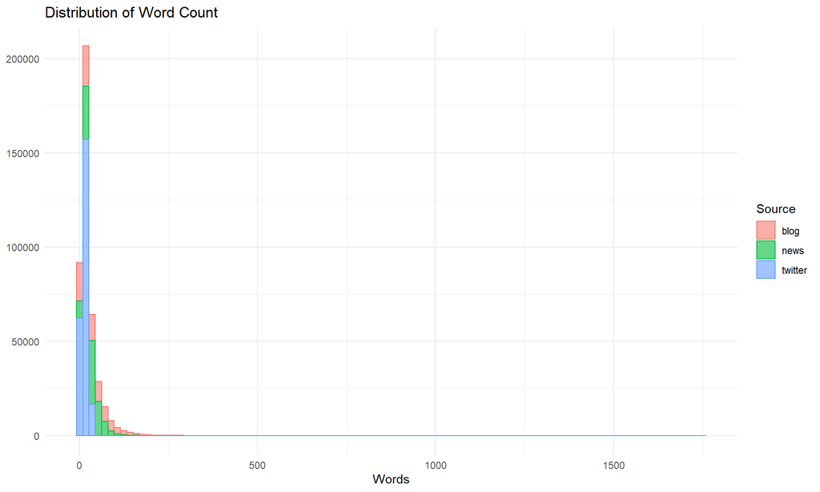

Distribution of word count is strongly exponential.

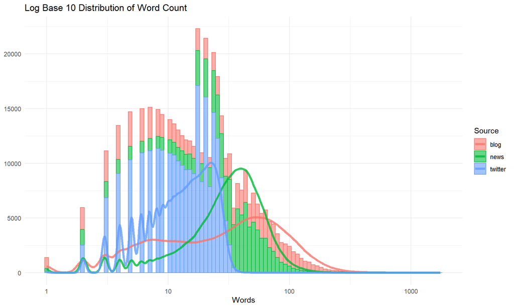

## 5.3 Most Common Words

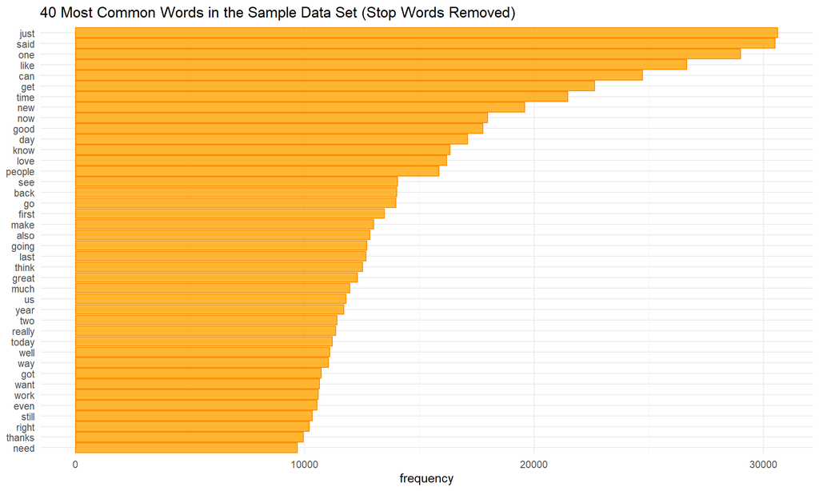

Looking at the size of the word count table gives us the number of unique words in the corpus:

- 211,231 unique words
- 211,056 unique words without stop words

## 5.4 Wordcloud

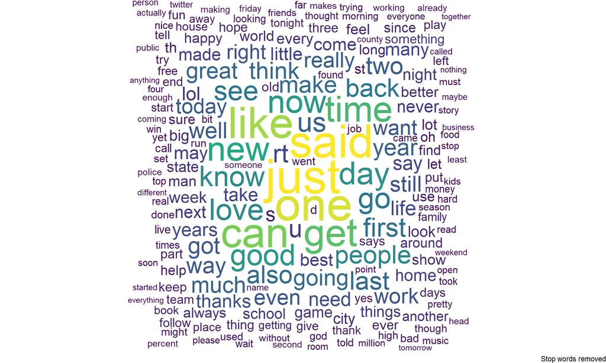

## 5.5 N-gram Analysis

### 5.5.1 Create a list of bi-grams and tri-grams.

Using the following formula for combinations with repetitions:

$$(1)\ {}_{n+r-1}C_r={\large\frac{(n+r-1)!}{r!(n-1)!}}\\$$

- 22,309,373,296 possible bi-grams
- 1,570,825,283,144,700 possible tri-grams

We’ll look at bi-grams and tri-grams occurring in the sample for both with and without stop words keeping only those that occur frequently enough to consider (40 times with stop words & 25 times without for this analysis).

Samples from the corpus:

```
[1] "romney_has, has_an, an_enormous, enormous_lead, lead_in, in_delegates, delegates_but, but_still"
[1] "washington_colorado, colorado_attorney, attorney_general, general_john, john_suthers, suthers_called, called_monday's, monday's_opening"
[1] "it's_not, not_uncommon, uncommon_for, for_utilities, utilities_universities, universities_and, and_even, even_state"
[1] "city_controller, controller_wendy, wendy_greuel, greuel_another, another_mayoral, mayoral_candidate, candidate_also, also_spoke"
[1] "dalia_some, some_people, people_take, take_the, the_jeans, jeans_too, too_far, far_they"
[1] ""
[1] "the_spanish, spanish_had, had_contact, contact_with, with_marino's, marino's_people, people_early, early_in"
[1] "forward_carmelo, carmelo_anthony, anthony_said, said_he, he_didn't, didn't_see, see_stoudemire, stoudemire_after"
[1] "french_interior, interior_minister, minister_michele, michele_alliot.marie, alliot.marie_said, said_friday, friday_that, that_having"
[1] "andrew's_father, father_danny, danny_had, had_kept, kept_the, the_secret, secret_of, of_his"
```

```
[1] "romney_enormous, enormous_lead, lead_delegates, delegates_still, still_must, must_reach, reach_ure, ure_nomination"
[1] "washington_colorado, colorado_attorney, attorney_general, general_john, john_suthers, suthers_called, called_monday's, monday's_opening"
[1] "uncommon_utilities, utilities_universities, universities_even, even_state, state_tax, tax_departments, departments_charge, charge_convenience"
[1] "city_controller, controller_wendy, wendy_greuel, greuel_another, another_mayoral, mayoral_candidate, candidate_also, also_spoke"
[1] "dalia_people, people_take, take_jeans, jeans_far, far_think, think_means, means_jeans, jeans_tennis"
[1] ""
[1] "spanish_contact, contact_marino's, marino's_people, people_early, early_th, th_century, century_december, december_indians"
[1] "forward_carmelo, carmelo_anthony, anthony_said, said_see, see_stoudemire, stoudemire_game, game_know, know_happened"
[1] "french_interior, interior_minister, minister_michele, michele_alliot.marie, alliot.marie_said, said_friday, friday_parliamentary, parliamentary_commission"
[1] "andrew's_father, father_danny, danny_kept, kept_secret, secret_son's, son's_return, return_home, home_deployment"
```

### 5.5.2 Frequency of n-grams

The following table displays the top 40 most frequently occurring bi-grams and tri-grams:

| Bigrams with Stopwords word1 | Bigrams with Stopwords word2 | Bigrams with Stopwords frequency | Bigrams w/o Stopwords word1 | Bigrams w/o Stopwords word2 | Bigrams w/o Stopwords frequency | Trigrams with Stopwords word1 | Trigrams with Stopwords word2 | Trigrams with Stopwords word3 | Trigrams with Stopwords frequency | Trigrams w/o Stopwords word1 | Trigrams w/o Stopwords word2 | Trigrams w/o Stopwords word3 | Trigrams w/o Stopwords frequency |
| --- | --- | --- | --- | --- | --- | --- | --- | --- | --- | --- | --- | --- | --- |
| of | the | 43098 | right | now | 2435 | one | of | the | 3508 | new | york | city | 273 |
| in | the | 41445 | new | york | 1990 | a | lot | of | 2939 | let | us | know | 265 |
| to | the | 21565 | last | year | 1857 | thanks | for | the | 2466 | happy | mother’s | day | 194 |
| for | the | 19950 | last | night | 1596 | to | be | a | 1815 | happy | mothers | day | 180 |
| on | the | 19650 | high | school | 1408 | going | to | be | 1708 | happy | new | year | 178 |
| to | be | 16152 | years | ago | 1388 | the | end | of | 1516 | president | barack | obama | 162 |
| at | the | 14362 | last | week | 1301 | as | well | as | 1475 | two | years | ago | 139 |
| and | the | 12653 | feel | like | 1273 | i | want | to | 1457 | cinco | de | mayo | 133 |
| in | a | 11958 | first | time | 1227 | out | of | the | 1434 | new | york | times | 126 |
| with | the | 10638 | looking | forward | 1118 | it | was | a | 1412 | world | war | ii | 125 |
| is | a | 10227 | can | get | 1099 | some | of | the | 1395 | st | louis | county | 108 |
| it | was | 9651 | looks | like | 1014 | be | able | to | 1333 | looking | forward | seeing | 104 |
| for | a | 9395 | make | sure | 1002 | part | of | the | 1288 | gov | chris | christie | 99 |
| i | have | 8798 | even | though | 940 | i | have | a | 1267 | first | time | since | 96 |
| from | the | 8699 | happy | birthday | 934 | i | have | to | 1162 | two | weeks | ago | 88 |
| i | was | 8503 | st | louis | 915 | looking | forward | to | 1100 | three | years | ago | 77 |
| with | a | 8280 | let | know | 850 | the | rest | of | 1090 | rock | n | roll | 72 |
| it | is | 8160 | good | morning | 848 | i | don’t | know | 1072 | keep | good | work | 69 |
| and | i | 8134 | new | jersey | 825 | the | first | time | 1021 | new | year’s | eve | 67 |
| will | be | 8071 | united | states | 805 | is | going | to | 1018 | five | years | ago | 66 |
| going | to | 8004 | just | got | 794 | thank | you | for | 1014 | martin | luther | king | 66 |
| of | a | 7993 | next | week | 779 | there | is | a | 989 | four | years | ago | 65 |
| i | am | 7676 | every | day | 765 | a | couple | of | 984 | come | see | us | 65 |
| have | a | 7506 | one | day | 744 | you | want | to | 983 | cant | wait | see | 65 |
| if | you | 7492 | can | see | 740 | i’m | going | to | 981 | county | sheriff’s | office | 61 |
| one | of | 7378 | good | luck | 734 | i | love | you | 969 | thanks | following | us | 60 |
| is | the | 7377 | los | angeles | 727 | this | is | a | 968 | past | two | years | 58 |
| to | get | 7112 | just | like | 715 | the | fact | that | 957 | couple | years | ago | 58 |
| as | a | 6806 | two | years | 709 | end | of | the | 922 | love | love | love | 58 |
| want | to | 6346 | look | like | 702 | it | would | be | 909 | high | school | students | 57 |
| by | the | 6239 | thanks | follow | 695 | i | need | to | 909 | george | w | bush | 57 |
| have | to | 6178 | next | year | 671 | you | have | to | 907 | st | patrick’s | day | 57 |
| that | the | 6029 | can | make | 619 | in | the | world | 872 | blah | blah | blah | 57 |
| this | is | 5924 | little | bit | 614 | can’t | wait | to | 854 | look | forward | seeing | 55 |
| to | do | 5868 | every | time | 599 | to | go | to | 853 | long | time | ago | 54 |
| and | a | 5765 | follow | back | 596 | this | is | the | 831 | just | got | back | 53 |
| i | think | 5755 | one | thing | 585 | one | of | my | 829 | wall | street | journal | 52 |
| the | first | 5676 | long | time | 576 | is | one | of | 818 | county | prosecutor’s | office | 52 |
| was | a | 5672 | sounds | like | 569 | for | the | follow | 818 | good | morning | everyone | 52 |
| i | don’t | 5535 | get | back | 564 | to | have | a | 815 | world | trade | center | 51 |

- Frequently occurring bi-gram count: 23,701 with stop words, 8,054 without stop words.
- Frequently occurring tri-gram count: 7,839 with stop words, 212 without stop words.
- Bigrams have a much higher frequency than trigrams (top trigram counts are approximately 10% of those for bigrams).
- N-grams without stopwords have a much lower frequency, particularly trigrams where the highest score (not counting proper nouns) occurred only 265 times in 427K observations (0.06%).

### 5.5.3 Relationships Between Words in Bigrams

Plot connections between words with and without stopwords.

```
## IGRAPH 8fdd5b4 DN-- 80 108 --
## + attr: name (v/c), word3 (e/c), frequency (e/n)
## + edges from 8fdd5b4 (vertex names):
##  [1] of   ->the   in   ->the   to   ->the   for  ->the   on   ->the
##  [6] to   ->be    at   ->the   and  ->the   in   ->a     with ->the
## [11] is   ->a     it   ->was   for  ->a     i    ->have  from ->the
## [16] i    ->was   with ->a     it   ->is    and  ->i     will ->be
## [21] going->to    of   ->a     i    ->am    have ->a     if   ->you
## [26] one  ->of    is   ->the   to   ->get   as   ->a     want ->to
## [31] by   ->the   have ->to    that ->the   this ->is    to   ->do
## [36] and  ->a     i    ->think the  ->first was  ->a     i    ->don't
## + ... omitted several edges
```

```
## IGRAPH 8fe0228 DN-- 100 87 --
## + attr: name (v/c), word3 (e/c), frequency (e/n)
## + edges from 8fe0228 (vertex names):
##  [1] right  ->now      new    ->york     last   ->year     last   ->night
##  [5] high   ->school   years  ->ago      last   ->week     feel   ->like
##  [9] first  ->time     looking->forward  can    ->get      looks  ->like
## [13] make   ->sure     even   ->though   happy  ->birthday st     ->louis
## [17] let    ->know     good   ->morning  new    ->jersey   united ->states
## [21] just   ->got      next   ->week     every  ->day      one    ->day
## [25] can    ->see      good   ->luck     los    ->angeles  just   ->like
## [29] two    ->years    look   ->like     thanks ->follow   next   ->year
## + ... omitted several edges
```

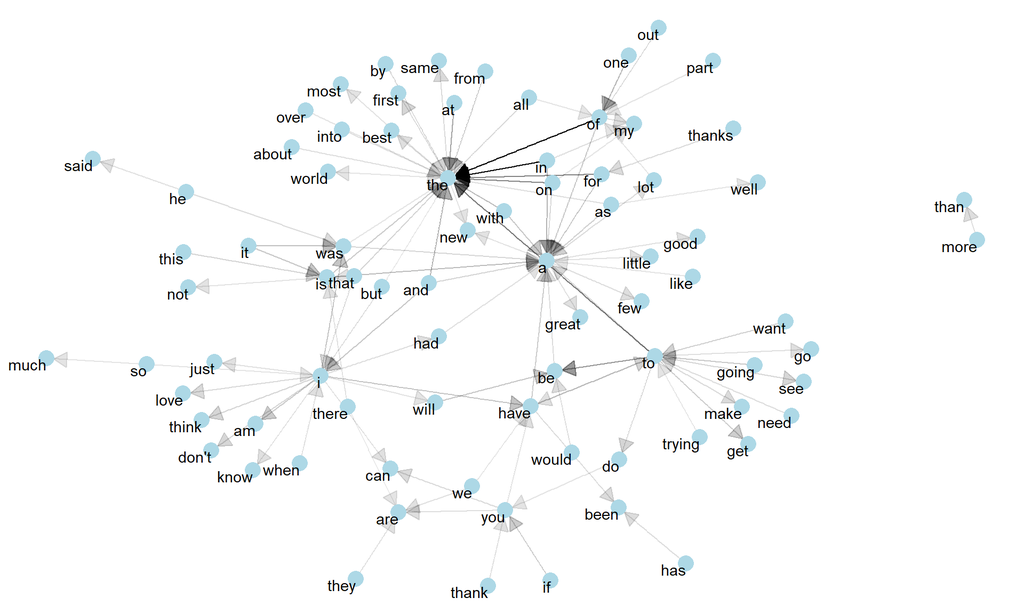

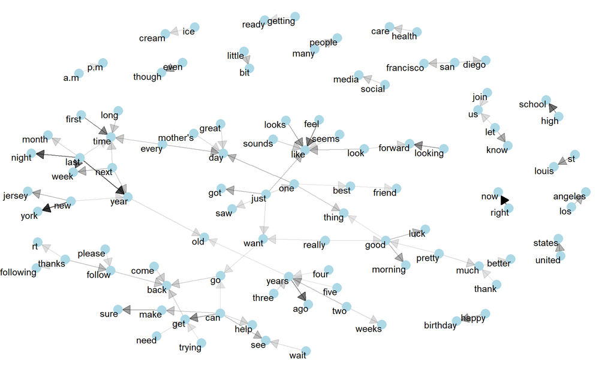

## 5.6 Feature Co-occurrence Matrix (FCM)

Another useful analysis is to use Collocation Frequency which analyses co-occurrence of words within the document (as opposed to n-grams which only considers adjacent words).

| Collocations with Stopwords collocation | Collocations with Stopwords count | Collocations with Stopwords length | Collocations with Stopwords lambda | Collocations without Stopwords collocation | Collocations without Stopwords count | Collocations without Stopwords length | Collocations without Stopwords lambda |
| --- | --- | --- | --- | --- | --- | --- | --- |
| of the | 43098 | 2 | 1.7897815 | right now | 2435 | 2 | 4.921475 |
| in the | 41445 | 2 | 2.0006764 | new york | 1990 | 2 | 9.357920 |
| to the | 21565 | 2 | 0.5581746 | last year | 1857 | 2 | 4.518750 |
| for the | 19950 | 2 | 1.5374918 | last night | 1596 | 2 | 4.854133 |
| on the | 19650 | 2 | 1.9036605 | high school | 1408 | 2 | 6.143525 |
| to be | 16152 | 2 | 2.7171194 | years ago | 1388 | 2 | 6.368092 |
| at the | 14362 | 2 | 1.9618189 | last week | 1301 | 2 | 4.561878 |
| and the | 12653 | 2 | 0.1130091 | feel like | 1273 | 2 | 4.131166 |
| in a | 11958 | 2 | 1.1759567 | first time | 1227 | 2 | 3.293214 |
| with the | 10638 | 2 | 1.2777167 | looking forward | 1118 | 2 | 6.931798 |
| is a | 10227 | 2 | 1.4774927 | can get | 1099 | 2 | 2.476897 |
| it was | 9651 | 2 | 3.1409912 | looks like | 1014 | 2 | 5.033158 |
| for a | 9395 | 2 | 1.3485377 | make sure | 1002 | 2 | 4.749336 |
| i have | 8798 | 2 | 2.4981628 | even though | 940 | 2 | 4.905264 |
| from the | 8699 | 2 | 1.7909021 | happy birthday | 934 | 2 | 6.525924 |
| i was | 8503 | 2 | 2.2523182 | st louis | 915 | 2 | 8.883394 |
| with a | 8280 | 2 | 1.6821337 | let know | 850 | 2 | 4.447955 |
| it is | 8160 | 2 | 2.3330645 | good morning | 848 | 2 | 4.376039 |
| and i | 8134 | 2 | 0.9401703 | new jersey | 825 | 2 | 6.146440 |
| will be | 8071 | 2 | 4.2629453 | united states | 805 | 2 | 9.187266 |
| going to | 8004 | 2 | 4.1497442 | just got | 794 | 2 | 2.794885 |
| of a | 7993 | 2 | 0.5152602 | next week | 779 | 2 | 4.516142 |
| i am | 7676 | 2 | 5.2009930 | every day | 765 | 2 | 3.720341 |
| have a | 7506 | 2 | 1.9089028 | one day | 744 | 2 | 2.179035 |
| if you | 7492 | 2 | 3.7418625 | can see | 740 | 2 | 2.557233 |
| one of | 7378 | 2 | 2.8619950 | good luck | 734 | 2 | 5.989462 |
| is the | 7377 | 2 | 0.4116014 | los angeles | 727 | 2 | 14.808728 |
| to get | 7112 | 2 | 2.7942008 | just like | 715 | 2 | 1.611962 |
| as a | 6806 | 2 | 1.8993038 | two years | 709 | 2 | 3.689750 |
| want to | 6346 | 2 | 3.9804638 | look like | 702 | 2 | 3.309687 |
| by the | 6239 | 2 | 1.6309077 | thanks follow | 695 | 2 | 4.664213 |
| have to | 6178 | 2 | 1.5172676 | next year | 671 | 2 | 3.865891 |
| that the | 6029 | 2 | 0.2374993 | can make | 619 | 2 | 2.428675 |
| this is | 5924 | 2 | 2.4790413 | little bit | 614 | 2 | 5.067210 |
| to do | 5868 | 2 | 2.4771676 | every time | 599 | 2 | 3.223041 |
| and a | 5765 | 2 | -0.0252936 | follow back | 596 | 2 | 4.101560 |
| i think | 5755 | 2 | 3.9429832 | one thing | 585 | 2 | 3.147544 |
| the first | 5676 | 2 | 2.7208205 | long time | 576 | 2 | 3.348739 |
| was a | 5672 | 2 | 1.4030182 | sounds like | 569 | 2 | 4.776484 |
| i don’t | 5535 | 2 | 3.5512796 | get back | 564 | 2 | 2.343143 |

As expected, stop words and bi-grams rate the highest.

Top features in the FCM’s:

```
      i      of     and     the      is       a     you      my      it     was
3781329 3038974 2953831 2550223 2281944 2215231 1812772 1657482 1604269 1590184
   have     for      we    with      be    this     one     who   about    that
1440665 1373846 1223847 1107883 1038409 1032843  927765  890596  877592  876655
```

```
     like       one      just    things      love      make     every     today
   213385    182524    146327    124638    122639    122321    108857     99118
    great    around      many      time      well       day      keep    little
    97714     94339     93521     89269     86399     85104     79296     76907
       go      life       god something
    76538     74719     74306     72359
```

Plot relationship between collocating words:

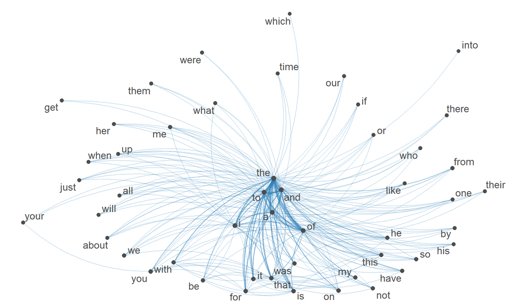

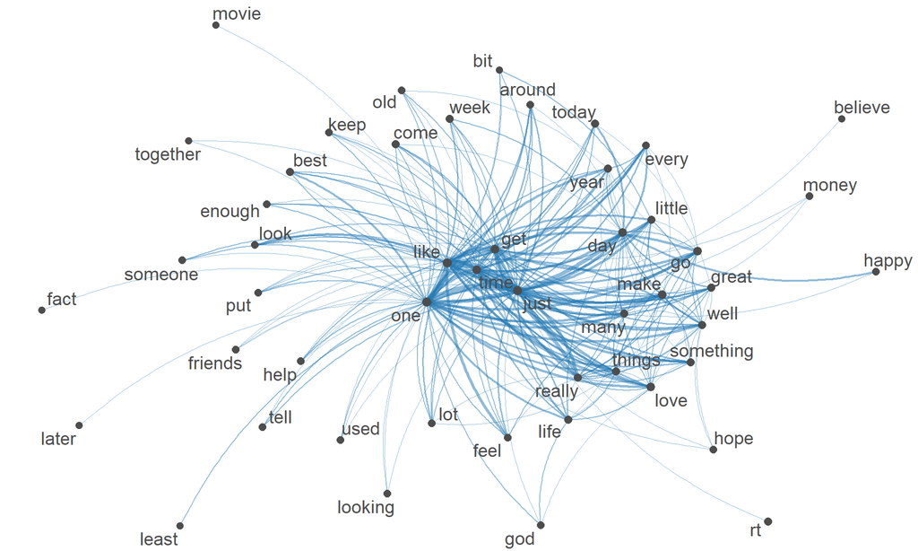

## 5.7 Term Frequency - Inverse Document Frequency (TF-IDF)

The statistic tf-idf is intended to measure how important a word is to a document in a collection (or corpus) of documents, for example, to one novel in a collection of novels or to one website in a collection of websites.

### 5.7.1 Term Frequency Calculation

Looking at the data split by source to see if there is much change in word importance, there is a similar distribution across all sources.

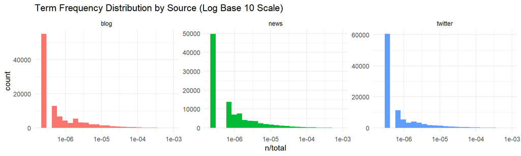

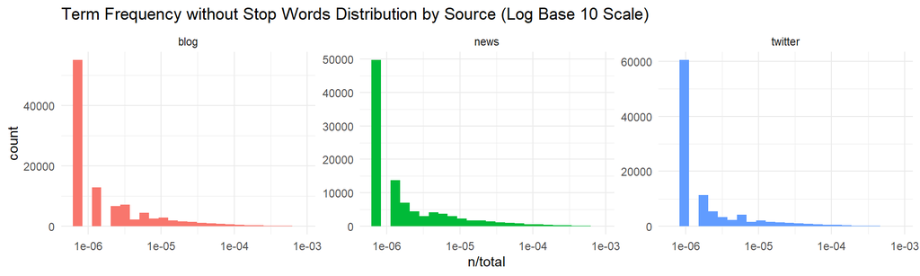

### 5.7.2 Zipf’s law

Zipf’s law states that the frequency that a word appears is inversely proportional to its rank.

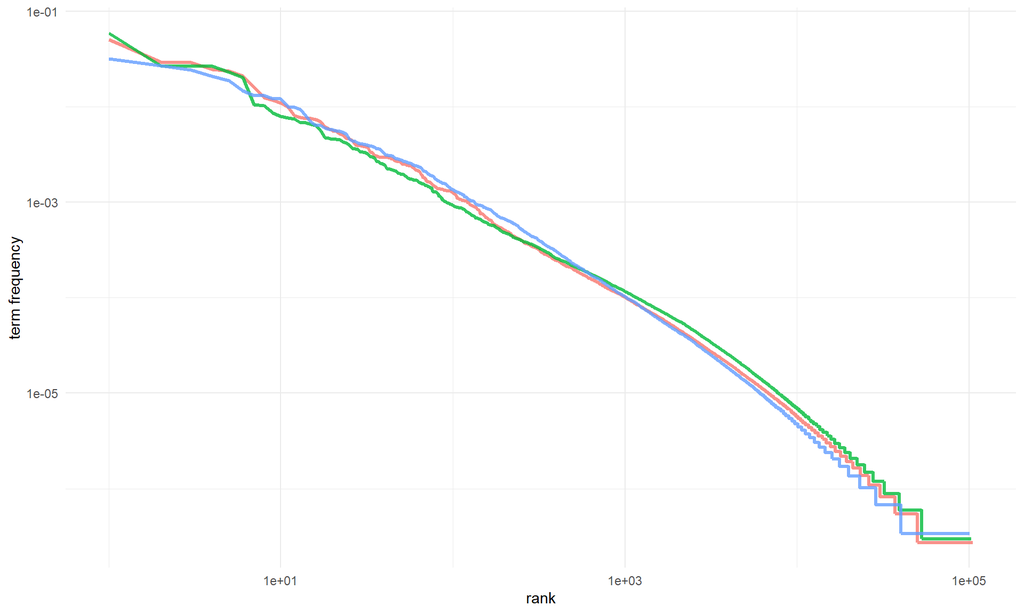

Plots for the three sources are nearly identical.

There is a near log-linear relationship over much of the distribution as predicted by Zipf’s Law.

Finding the linear relationship for ranks from 10 to 10000:

```
## (Intercept) log10(rank)
##  -0.4374398  -1.1858634
```

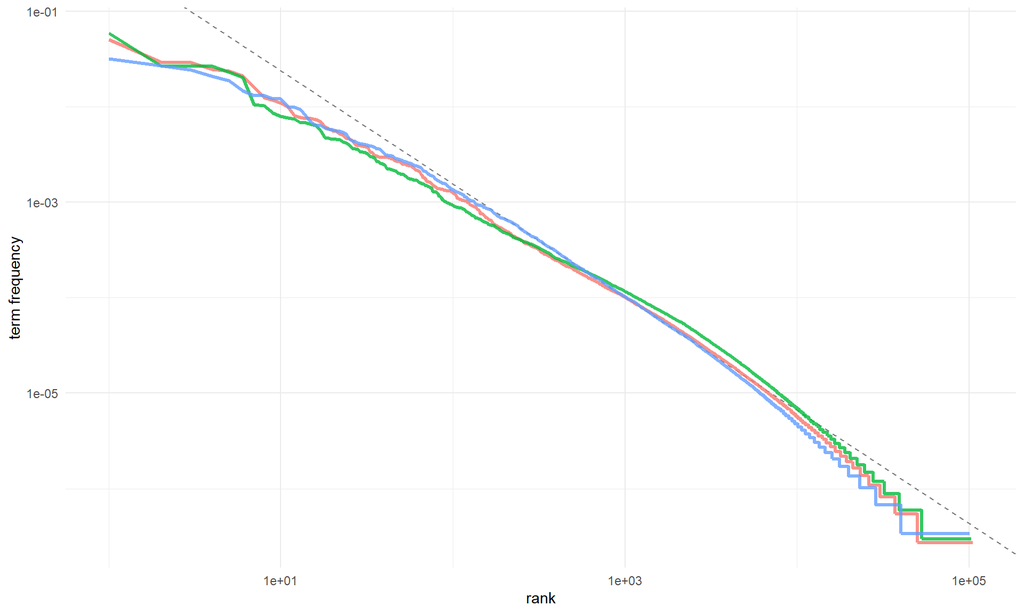

### 5.7.3 TF-IDF

Find Words with Highest TF-IDF Score:

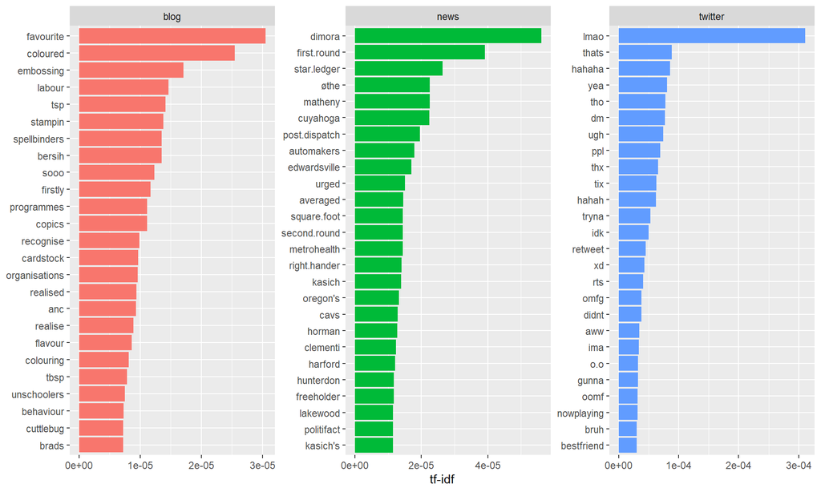

Interesting to note, the highest ranking words for Twitter are mostly “junk” words not found in a standard English dictionary.

## 5.8 Analysing Language

The English dictionary from the `hunspell` package is loaded and tokens filtered by dictionary words only.

82.8% of words in the sample are recognised in the US English dictionary (comprising of 49,271 word definitions). The remaining 17.2% will be a mixture of foreign words, abbreviations, shorthand, mispellings and unrecognised slang. Determining the proportion of these that are actually foreign words would require a significant amount of processing.

68% of the words appearing in the US English dictionary are captured by a 10% sample. To capture 90% of vocabulary would likely require a far greater sample as frequency of usage of remaining words becomes increasingly rare.

Everyday words are a much smaller subset of the full dictionary vocabulary however.

> “In English, for example, 3000 words make up about 95% of everyday conversation”[^1]

There are 33,482 US English words captured in the sample. Using 3000 as an estimate of common usage vocabulary, it is very likely that nearly all are captured by the sample.

Using the [Top 3000 Words list from Education First](https://www.ef.co.uk/english-resources/english-vocabulary/top-3000-words/):

The 10% sample captures 98.2% of common usage words, 68.7% of the content is in the English common usage list.

Below is an estimation of the required sample size to meet common vocabulary coverage. Rather than looking at the required number of words to be sampled, the document frequency count is used to estimate the number of documents (text samples) that would need to be sampled to achieve coverage.

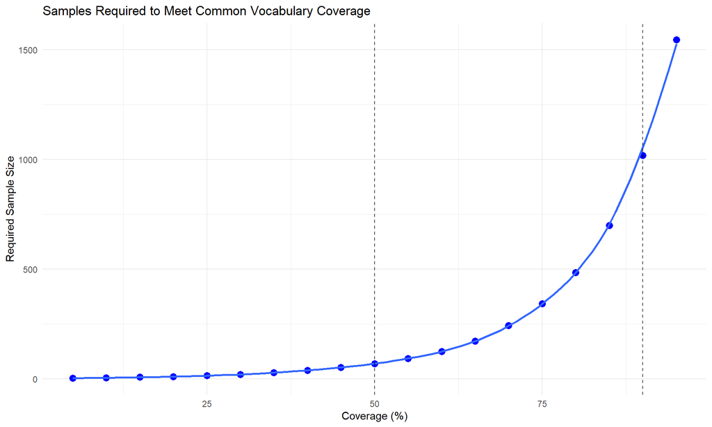

- Samples required to capture 50% of common usage words: 69
- Samples required to capture 90% of common usage words: 1018
- The number of samples required grows exponentially with coverage required.

While this looks at word capture rate, n-gram capture rate significantly drops off for lower sample sizes.

## 5.10 Further Thoughts

- Even with a sample size of 426,714, the number of encountered tri-grams is relatively low.
- Vectorising the vocabulary in the model will be necessary (words are indexed and represented as digits).
- Constructing a probability matrix of expected n-grams is not feasible as the memory required for such a matrix would run into hundreds of gigabytes (a test of a vectorised feature sequence matrix on only 11,000 words needed 176GB memory).
- Basic n-gram matrices do not take unknown words into consideration, some form of algorithm to deal with this is required.

# 6 Creating a Prediction Algorithm

## 6.1 Trialled Model Types

### 6.1.1 Long Short-term Memory (LTSM)

Long short-term memory (LSTM) is an artificial recurrent neural network (RNN) architecture available in R through the Tensor Flow Keras package.

The huge advantage of the RNN models is that they use unsupervised learning to take past choices into account, including new vocabulary terms to build a smart, personalised self-teaching model.

I had high hopes for this but quickly ran into memory issues when trying to build the feature matrix for any sample over a few thousand sentences. A Windows laptop is not the right environment for this pursuit, neither is R, where both have tight restrictions on memory usage.

Most text prediction using this model is character based rather than word based and has a tendency to produce nonsense words.

Of the few working models I managed, training the model in small batches, prediction accuracy was low, memory usage high and response times too long to be considered practical.

Final nail in the coffin for this approach was the discovery that the Shiny Apps servers do not support Keras.

### 6.1.2 Markov-Chain with Katz’s Back-off

This route similarly has memory issues, and still requires large scale n-gram and skip-gram matrices taking too much memory and in the end, not producing great results - 33% prediction rate was the best I saw here and not so quick to respond.

### 6.1.3 Stupid Back-off Model

Markov models are the class of probabilistic models that assume we can predict the probability of some future unit without looking too far into the past. Stupid back-off is a smoothing model does away with the need to store vast amounts of probabilistic data and instead uses direct relative frequencies. Katz’s Back-off may require up to 4 searches and calculations per request while the Stupid Back-off will only ever require one and making use of pre-compiled C++ code, the execution time is much quicker.

Stupid back-off takes care of unknown words by splitting chains in to linked segments thus getting rid of the need for skip-grams.

In terms of accuracy, my first model (below) was trained on a 5% sample using default parameters gave me a 46% accuracy and typical response time of 2.5ms.

## 6.2 Testing the Initial Model

For training the initial model, the train data is split 50-50 to give a 5% sample of the original data source. It is then split into sentences, stripped of any excess whitespace and any sentences shorter than 4 words are removed (since our aim to predict on the previous 3 words.

Next, an SBO predictor table is trained with 4-grams, a target of 75% coverage of the source vocabulary and a lambda penalization of 0.4. A predictor model is generated from that table.

Below, we show some example predictions and also test the memory allocation and amount of time to respond:

```
[1] "information about the [ event, new, people ]"
```

```
[1] "i'd like to [ see, be, share ]"
```

```
[1] "they wanted to [ be, get, know ]"
```

```
[1] "Model Memory Allocation:  38.6 MB"
```

| test | replications | elapsed | relative | user.self | sys.self |
| --- | --- | --- | --- | --- | --- |
| Test1 | 1000 | 2.56 | 1.028 | 2.52 | 0.02 |
| Test2 | 1000 | 2.49 | 1.000 | 2.48 | 0.00 |
| Test3 | 1000 | 2.89 | 1.161 | 2.89 | 0.00 |

Note, there are 1000 replications in the above benchmark test, the times displayed above can be thought of as the average time for each request in milliseconds.

Evaluating the accuracy for in-sample data:

```
## # A tibble: 198,772 x 4
##    input                      true         preds[,1] [,2]    [,3]    correct
##    <chr>                      <chr>        <chr>     <chr>   <chr>   <lgl>
##  1 "met those limits"         before       before    <EOS>   are     TRUE
##  2 "team and the"             other        first     other   game    TRUE
##  3 "dab stencil brush"        in           <EOS>     and     the     FALSE
##  4 "potential foreclosure of" another      the       my      another TRUE
##  5 "he even ordered"          the          the       to      a       TRUE
##  6 "of what legislators"      want         to        was     <EOS>   FALSE
##  7 "pm pm monday"             to           to        through <EOS>   TRUE
##  8 "responding to a"          conservation new       record  victory FALSE
##  9 "  prepeyton"              years        is        i       the     FALSE
## 10 "to resolve those"         cases        who       are     and     FALSE
## # ... with 198,762 more rows
```

```
## # A tibble: 1 x 2
##   accuracy uncertainty
##      <dbl>       <dbl>
## 1    0.459     0.00112
```

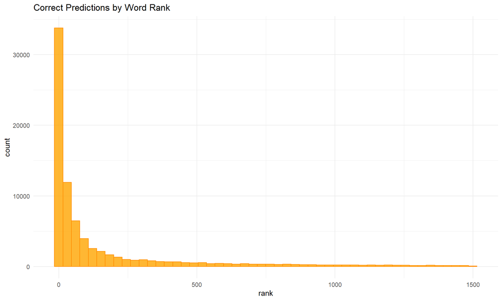

## 6.3 Considerations for Improvement

There are several avenues to explore to improve model accuracy and performance:

- Consider training the data with news and blog data only - the Twitter data tends to contain a lot of slang and abbreviations that could be inflating the vocabulary size.
- Trial a larger sample size and also greater target dictionary coverage.
- Test different values for the penalty value lambda.
- Detect end-of-sentence punctuation in the user input and capitalize suggestions where appropriate.

Ideal improvements beyond the scope of this project:

- Self-learning dictionary with weighting for user defined words and previously selected predictions.

# 7 References

(Benoit et al. 2018)

(Silge and Robinson 2016)

(Gherardi 2020)

[Large Language Models in Machine Translation](https://aclanthology.org/D07-1090.pdf)

[N-gram Language Models](https://web.stanford.edu/~jurafsky/slp3/3.pdf)

[Backoff Inspired Features for Maximum Entropy Language Models](https://static.googleusercontent.com/media/research.google.com/en//pubs/archive/43114.pdf)

Benoit, Kenneth, Kohei Watanabe, Haiyan Wang, Paul Nulty, Adam Obeng, Stefan Müller, and Akitaka Matsuo. 2018. “Quanteda: An r Package for the Quantitative Analysis of Textual Data” 3: 774. https://doi.org/10.21105/joss.00774.

Gherardi, Valerio. 2020. “Sbo: Text Prediction via Stupid Back-Off n-Gram Models.” https://CRAN.R-project.org/package=sbo.

Silge, Julia, and David Robinson. 2016. “Tidytext: Text Mining and Analysis Using Tidy Data Principles in r” 1. https://doi.org/10.21105/joss.00037.

[^1]: https://www.fluentu.com/blog/how-many-words-do-i-need-to-know/